# Description

This file reports the analysis of the output data acquired from processing rodent EEG data using the SCPP4V2 processor.

SCPP4V2 has been optimised to run on 8s intervals and the files in the NeuroarchiverAnalysis repository specify this interval length. The glitch threshold is set to 200

For each data file (.ndf), SCPP4V2 generates a text file, containing: loss| spike counts| burst count| delta power (0.1 - 3.9 Hz)| theta power (4 - 12Hz) | gamma1 power (20-80 Hz, based on Verret et al 2016) | gamma2 power (40-80 Hz)| broadband1 power (5- 160Hz; to avoid low frequency power arising from artifacts)| broadband2 power (0.1 - 160Hz). Each row is a consecutive 8s interval.

The present analysis takes input of files “ndfFilename_SCPP4V2.txt”, organised in individual folders by AnimalID.

Plots are saved to Outputs/Figures

## Housekeeping

First, load packages and source files

```
## AddVideoScoreToSCPPData.R :
## CalculateSpikeRate.R :
## ConvertToRadians.R :
## ConvertToSeconds.R :
## ConvertUnixSecondsToTimeOfDay.R :
## CopyToLocalDataDir.R :
## CreateECDF.R :
## ECDFlistToDF.R :
## ExcludeIntervals.R :
## ExcludeLossIntervals.R :
## GetTimeOfDayaAndDate.R :
## HampelFilter.R :
## ImportData.R :
## LightsOnVar.R :
## montecarlo_xcorr.R :
## NormTest.R :
## RemoveOutliers.R :
## SpikeRateStats.R :
## SummaryCircStats.R :
## SummarySE.R :
```

Specify files and folders to be used

```r
NDFDataParentFolder<-"C:/Users/ioren/Dropbox/Analysis/Neuroarchiver/CDKL5/CDKL5_SCPP4V2"  #SPECIFY THE PARENT DIRECTORY OF THE SCPP4V2 PROCESSOR OUTPUT FILES
RecordingInfoFile<-"./Data/RecordingInfo.csv"
OutputFolder<-"./Output"  #Folder where analysis outputs are saved
```

Set thresholds and variables

```r
FalsePositiveCutOff=0.1  #Threshold for excluding animal based on high false positive rate. Between 0-1
LossIntervalPercentageThreshold<-5 #Limit for percent of intervals lost to include animal in analysis in %
LossThreshold<-20  #Threshold for packet loss within an interval for exclusion
DeltaThreshold<-1000  #Threshold for delta power within an interval for exclusion. Units: Counts

LightsOn<-7
LightsOff<-19
```

Import summary recording information dataframe as SummaryDataframe

```
## data.table + dplyr code now lives in dtplyr.
## Please library(dtplyr)!
```

The dataset used in analysis is from the following animals

```r
SummaryDataframe
```

| AnimalID | Transmitter | Genotype |
| --- | --- | --- |
| CDKL5_345 | 23 | WT |
| CDKL5_346 | 24 | KO |
| CDKL5_353 | 25 | WT |
| CDKL5_354 | 26 | KO |
| CDKL5_357 | 27 | KO |
| CDKL5_358 | 28 | WT |

If Output/DataframeAll.csv does not exist, we import data for each 8s interval for all animal IDs to create DataframeAll that is used in all analysis. Else, we import DataframeAll into the workspace. If you want to reimport data, then delete Output/DataframeAll.csv

Normalise by broadband power.. We use two normalisations. Median of Broadband1=5-160Hz, Broadband2=0.1-160Hz.Broadband1 normalisation will avoid contamination arising from artifacts

The genotypes used

```
## [1] WT KO
## Levels: KO WT
```

## Example traces

We can plot example traces which have been exported using the neuroarchiver Export.tcl. The following chunks plot traces which have been manually identified as sleep and wake. If included, change the value of “include =FALSE” to “TRUE”, and specify the filenames to be used. The chunks below are for 2 genotypes. Can be copied to add more genotypes.

```r
IncludeExampleTraces=TRUE
```

### WT

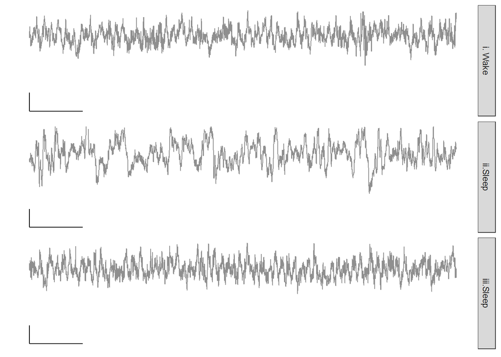

### KO

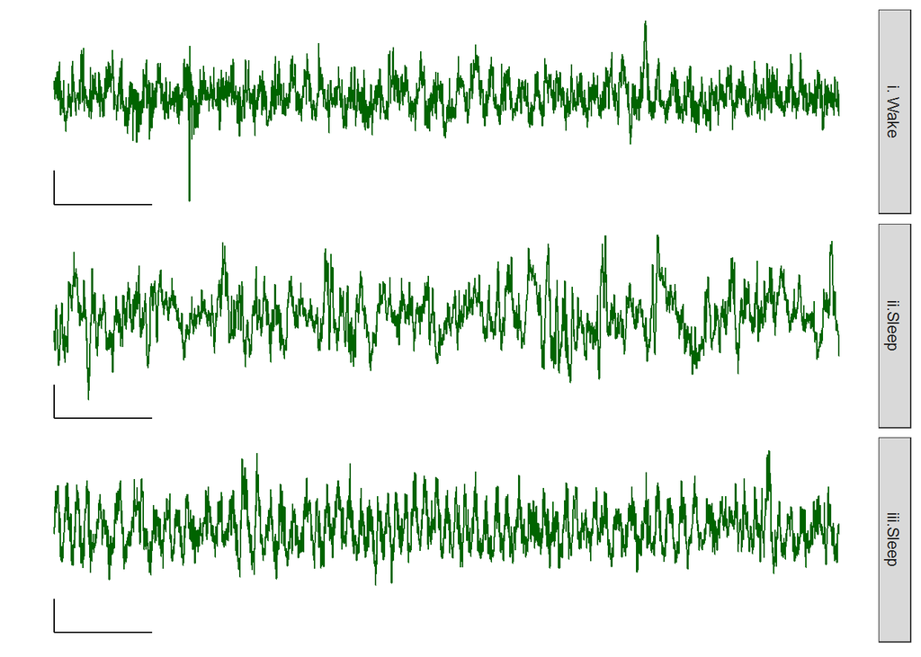

## Analysis of spectral features and spikes across recording

### Summary data

#### Unnormalised powers and SpikeAndBurstCount

| AnimalIDVariable | Genotype | num | MeanTheta | SEMTheta | CI_LTheta | CI_UTheta | MeanDelta | SEMDelta | CI_LDelta | CI_UDelta | MeanGamma1 | SEMGamma1 | CI_LGamma1 | CI_UGamma1 | MeanGamma2 | SEMGamma2 | CI_LGamma2 | CI_UGamma2 | MeanThetaOverDelta | SEMThetaOverDelta | CI_LThetaOverDelta | CI_UThetaOverDelta | MeanSpikeAndBurst | SEMSpikeAndBurst | CI_LSpikeAndBurst | CI_USpikeAndBurst |
| --- | --- | --- | --- | --- | --- | --- | --- | --- | --- | --- | --- | --- | --- | --- | --- | --- | --- | --- | --- | --- | --- | --- | --- | --- | --- | --- |
| CDKL5_345 | WT | 52584 | 14.84944 | 0.03938391 | 14.92663 | 14.77225 | 38.70392 | 0.50072301 | 39.68534 | 37.72249 | 4.793556 | 0.007373809 | 4.808008 | 4.779103 | 2.011400 | 0.003367434 | 2.018000 | 2.004799 | 1.7416356 | 0.007839204 | 1.7416356 | 1.7570005 | 0.03702647 | 0.0009495192 | 0.038887538 | 0.035165406 |
| CDKL5_346 | KO | 54373 | 24.15015 | 0.04019281 | 24.22893 | 24.07137 | 22.08800 | 0.07688325 | 22.23869 | 21.93731 | 6.967799 | 0.007148378 | 6.981810 | 6.953788 | 2.778323 | 0.004307775 | 2.786766 | 2.769880 | 1.8523620 | 0.008593792 | 1.8523620 | 1.8692059 | 0.00248285 | 0.0002150052 | 0.002904262 | 0.002061438 |
| CDKL5_353 | WT | 53569 | 16.61285 | 0.03429723 | 16.68008 | 16.54563 | 14.72908 | 0.17467395 | 15.07144 | 14.38672 | 5.711708 | 0.006058107 | 5.723582 | 5.699834 | 2.521091 | 0.004146033 | 2.529217 | 2.512964 | 2.2592023 | 0.012754211 | 2.2592023 | 2.2842006 | 0.01142452 | 0.0004674413 | 0.012340707 | 0.010508329 |
| CDKL5_354 | KO | 53417 | 23.06615 | 0.04276518 | 23.14997 | 22.98233 | 34.53719 | 0.25634597 | 35.03963 | 34.03475 | 7.148093 | 0.010625474 | 7.168919 | 7.127267 | 2.733766 | 0.005335090 | 2.744222 | 2.723309 | 1.1332900 | 0.003927018 | 1.1332900 | 1.1409870 | 0.06872344 | 0.0012758634 | 0.071224143 | 0.066222737 |
| CDKL5_357 | KO | 53738 | 16.89127 | 0.03311340 | 16.95617 | 16.82636 | 25.53832 | 0.32485143 | 26.17504 | 24.90161 | 8.354371 | 0.007776469 | 8.369613 | 8.339129 | 3.981470 | 0.005860964 | 3.992957 | 3.969982 | 2.0574771 | 0.008346601 | 2.0574771 | 2.0738365 | 0.00545238 | 0.0003219958 | 0.006083494 | 0.004821266 |
| CDKL5_358 | WT | 53801 | 15.53950 | 0.02303596 | 15.58465 | 15.49435 | 34.14046 | 0.25811968 | 34.64637 | 33.63454 | 4.440434 | 0.004735603 | 4.449716 | 4.431152 | 1.891737 | 0.003063601 | 1.897741 | 1.885732 | 0.7488286 | 0.002389226 | 0.7488286 | 0.7535115 | 0.01052025 | 0.0004499657 | 0.011402187 | 0.009638314 |

#### Normalised by broadband 1

| AnimalIDVariable | Genotype | num | MeanThetaNorm1 | SEMThetaNorm1 | CI_LThetaNorm1 | CI_UThetaNorm1 | MeanDeltaNorm1 | SEMDeltaNorm1 | CI_LDeltaNorm1 | CI_UDeltaNorm1 | MeanGamma1Norm1 | SEMGamma1Norm1 | CI_LGamma1Norm1 | CI_UGamma1Norm1 | MeanGamma2Norm1 | SEMGamma2Norm1 | CI_LGamma2Norm1 | CI_UGamma2Norm1 |
| --- | --- | --- | --- | --- | --- | --- | --- | --- | --- | --- | --- | --- | --- | --- | --- | --- | --- | --- |
| CDKL5_345 | WT | 52584 | 0.7736904 | 0.002051993 | 0.7777124 | 0.7696685 | 2.0165641 | 0.026088835 | 2.0676985 | 1.9654298 | 0.2497554 | 0.0003841926 | 0.2505084 | 0.2490024 | 0.10479861 | 0.0001754511 | 0.10514249 | 0.10445472 |
| CDKL5_346 | KO | 54373 | 0.7456741 | 0.001241017 | 0.7481065 | 0.7432417 | 0.6820020 | 0.002373892 | 0.6866548 | 0.6773491 | 0.2151418 | 0.0002207175 | 0.2155745 | 0.2147092 | 0.08578512 | 0.0001330094 | 0.08604582 | 0.08552442 |
| CDKL5_353 | WT | 53569 | 0.7060286 | 0.001457596 | 0.7088855 | 0.7031717 | 0.6259703 | 0.007423457 | 0.6405203 | 0.6114203 | 0.2427415 | 0.0002574631 | 0.2432461 | 0.2422369 | 0.10714367 | 0.0001762020 | 0.10748903 | 0.10679832 |
| CDKL5_354 | KO | 53417 | 0.8036704 | 0.001490024 | 0.8065909 | 0.8007500 | 1.2033446 | 0.008931604 | 1.2208506 | 1.1858386 | 0.2490538 | 0.0003702127 | 0.2497794 | 0.2483282 | 0.09524984 | 0.0001858852 | 0.09561418 | 0.09488550 |
| CDKL5_357 | KO | 53738 | 0.6202271 | 0.001215885 | 0.6226103 | 0.6178440 | 0.9377368 | 0.011928157 | 0.9611161 | 0.9143575 | 0.3067625 | 0.0002855427 | 0.3073222 | 0.3062029 | 0.14619482 | 0.0002152076 | 0.14661663 | 0.14577301 |
| CDKL5_358 | WT | 53801 | 0.8198965 | 0.001215426 | 0.8222788 | 0.8175143 | 1.8013220 | 0.013618935 | 1.8280152 | 1.7746288 | 0.2342866 | 0.0002498603 | 0.2347763 | 0.2337969 | 0.09981200 | 0.0001616420 | 0.10012882 | 0.09949518 |

#### Normalised by broadband 2

| AnimalIDVariable | Genotype | num | MeanThetaNorm2 | SEMThetaNorm2 | CI_LThetaNorm2 | CI_UThetaNorm2 | MeanDeltaNorm2 | SEMDeltaNorm2 | CI_LDeltaNorm2 | CI_UDeltaNorm2 | MeanGamma1Norm2 | SEMGamma1Norm2 | CI_LGamma1Norm2 | CI_UGamma1Norm2 | MeanGamma2Norm2 | SEMGamma2Norm2 | CI_LGamma2Norm2 | CI_UGamma2Norm2 |
| --- | --- | --- | --- | --- | --- | --- | --- | --- | --- | --- | --- | --- | --- | --- | --- | --- | --- | --- |
| CDKL5_345 | WT | 52584 | 0.4685031 | 0.0012425710 | 0.4709386 | 0.4660677 | 1.2211171 | 0.015797921 | 1.2520811 | 1.1901530 | 0.15123774 | 0.0002326453 | 0.15169372 | 0.15078175 | 0.06346010 | 1.062433e-04 | 0.06366834 | 0.06325186 |
| CDKL5_346 | KO | 54373 | 0.4526993 | 0.0007534221 | 0.4541760 | 0.4512226 | 0.4140439 | 0.001441192 | 0.4168686 | 0.4112191 | 0.13061276 | 0.0001339978 | 0.13087540 | 0.13035012 | 0.05208021 | 8.075010e-05 | 0.05223848 | 0.05192194 |
| CDKL5_353 | WT | 53569 | 0.4620971 | 0.0009539994 | 0.4639670 | 0.4602273 | 0.4096988 | 0.004858667 | 0.4192218 | 0.4001758 | 0.15887479 | 0.0001685101 | 0.15920507 | 0.15854451 | 0.07012575 | 1.153246e-04 | 0.07035178 | 0.06989971 |
| CDKL5_354 | KO | 53417 | 0.4104954 | 0.0007610682 | 0.4119871 | 0.4090037 | 0.6146392 | 0.004562047 | 0.6235809 | 0.6056976 | 0.12721063 | 0.0001890957 | 0.12758126 | 0.12684000 | 0.04865131 | 9.494563e-05 | 0.04883740 | 0.04846521 |
| CDKL5_357 | KO | 53738 | 0.4170786 | 0.0008176350 | 0.4186812 | 0.4154760 | 0.6305915 | 0.008021221 | 0.6463131 | 0.6148698 | 0.20628585 | 0.0001920163 | 0.20666220 | 0.20590950 | 0.09831032 | 1.447187e-04 | 0.09859397 | 0.09802667 |
| CDKL5_358 | WT | 53801 | 0.3299257 | 0.0004890863 | 0.3308843 | 0.3289671 | 0.7248504 | 0.005480248 | 0.7355918 | 0.7141091 | 0.09427672 | 0.0001005436 | 0.09447379 | 0.09407966 | 0.04016426 | 6.504461e-05 | 0.04029175 | 0.04003678 |

### Plots

#### Delta power

Mean delta power per animal unnormalised. Error bars=95% CI

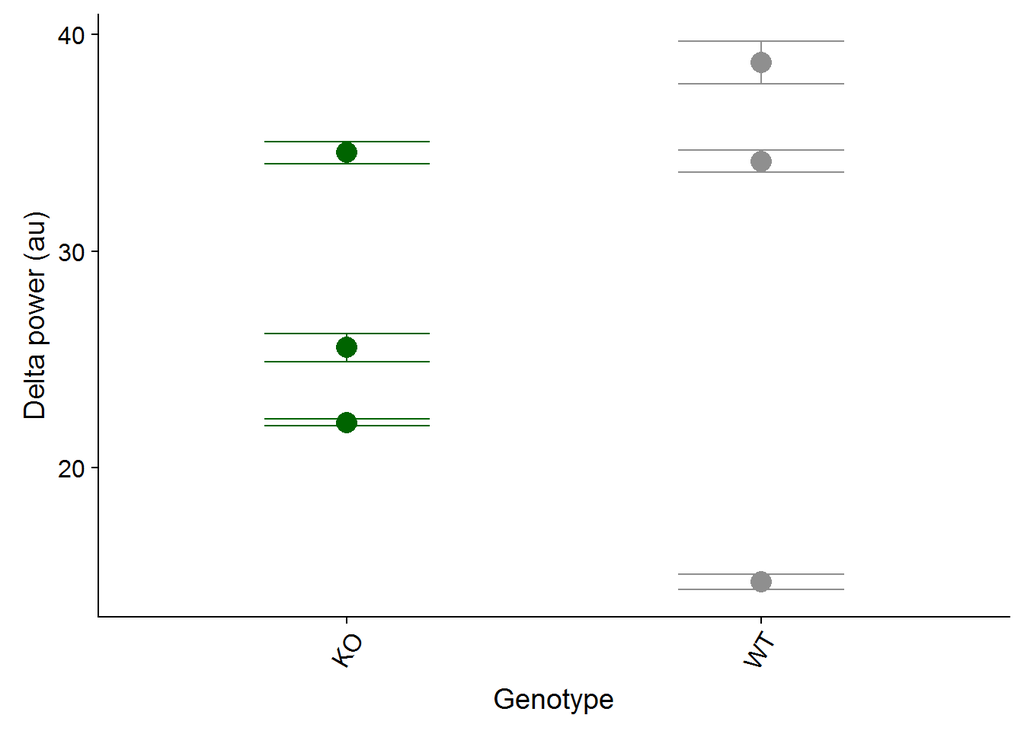

Mean delta power per animal normalised by Broadband1. Error bars=95% CI

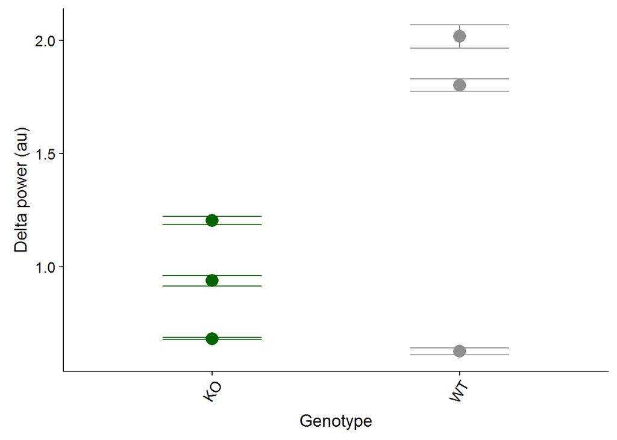

Mean delta power per animal normalised by Broadband2. Error bars=95% CI

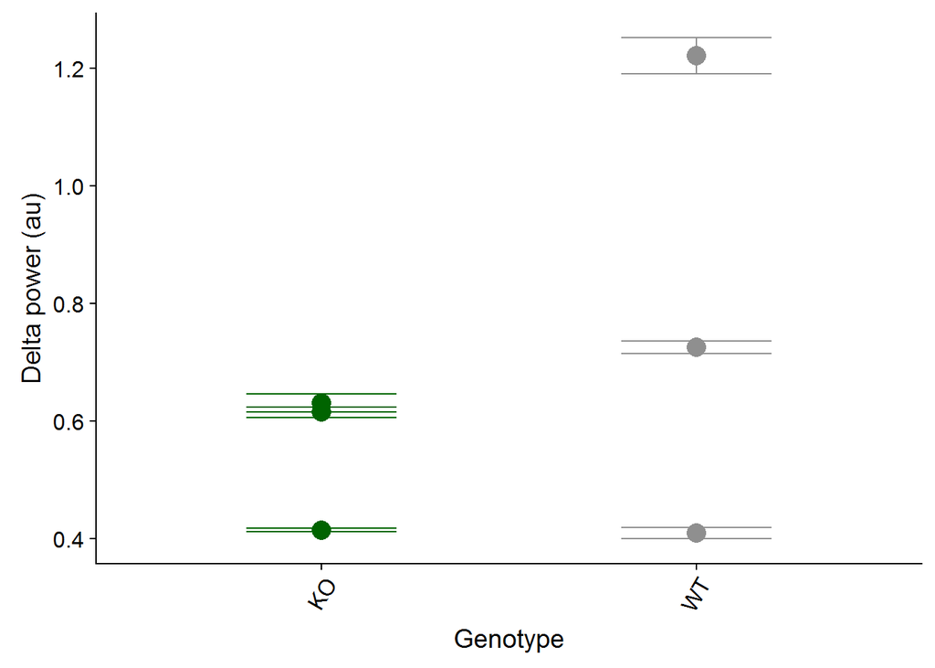

#### Theta power

Mean theta power per animal unnormalised. Error bars=95% CI

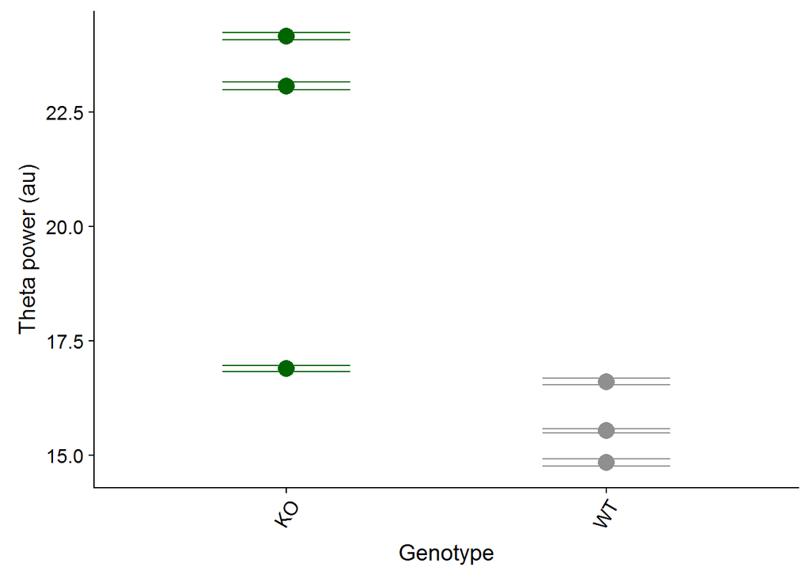

Mean theta power per animal normalised by Broadband1. Error bars=95% CI

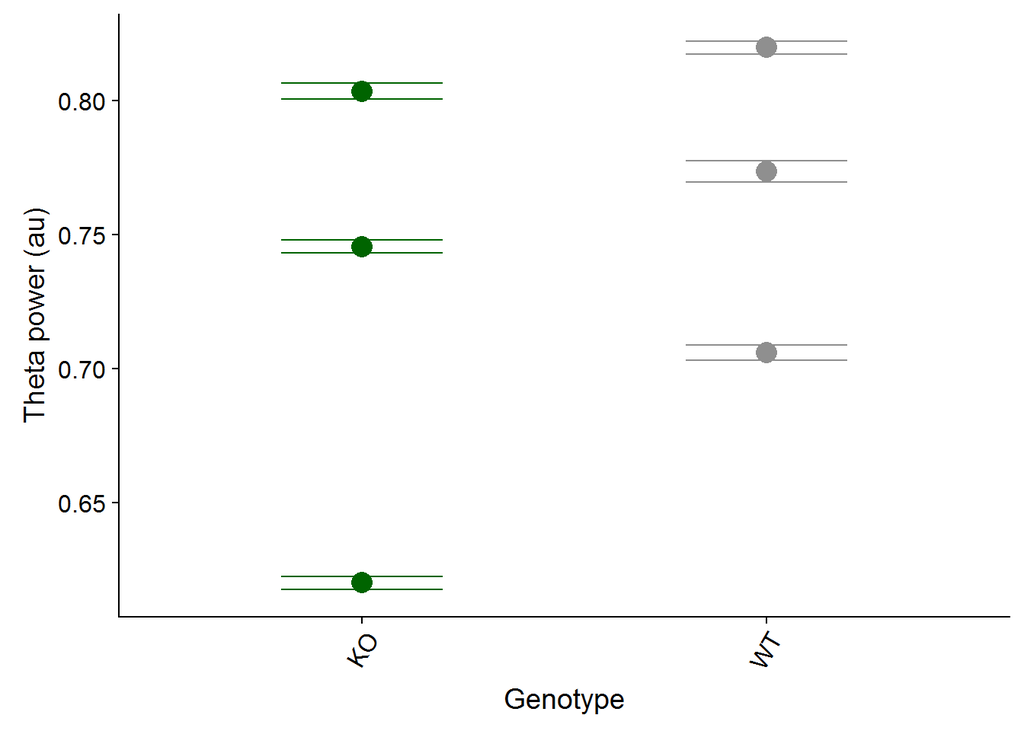

Mean theta power per animal normalised by Broadband2. Error bars=95% CI

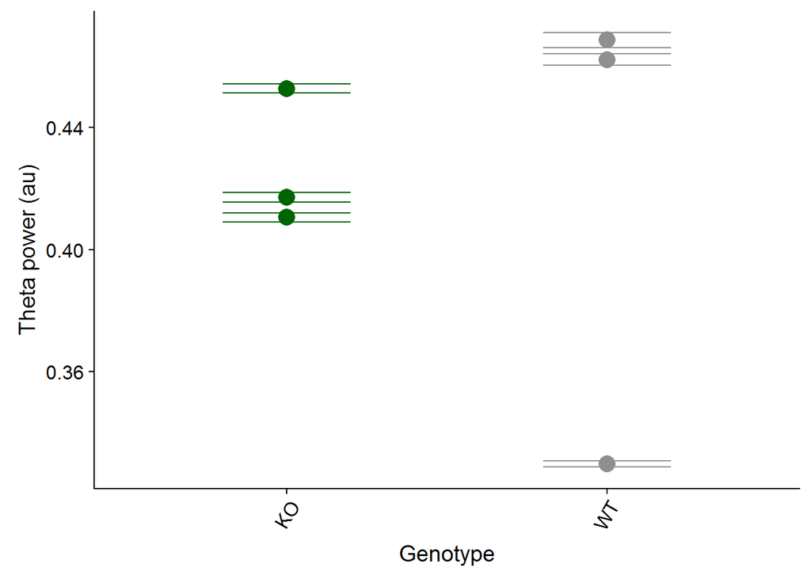

#### Gamma power

Mean gamma1 power per animal unnormalised. Error bars=95% CI

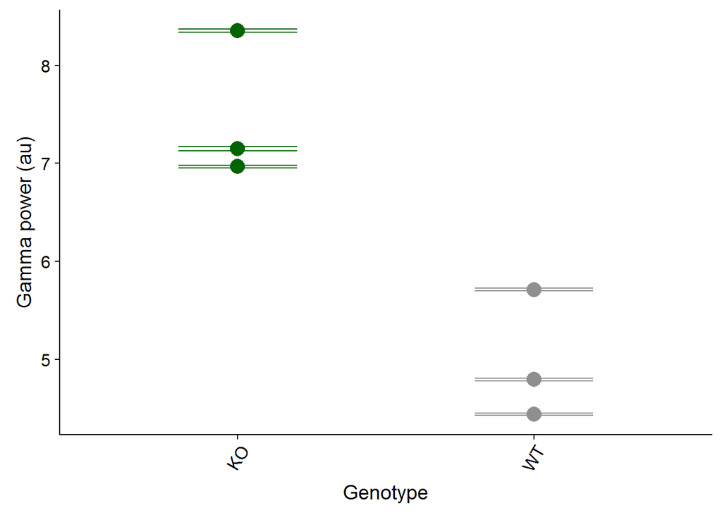

Mean gamma1 power per animal normalised by Broadband1. Error bars=95% CI

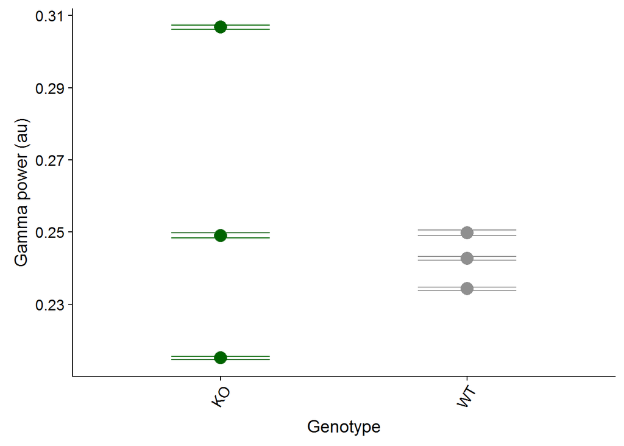

Mean gamma2 power per animal normalised by Broadband1. Error bars=95% CI

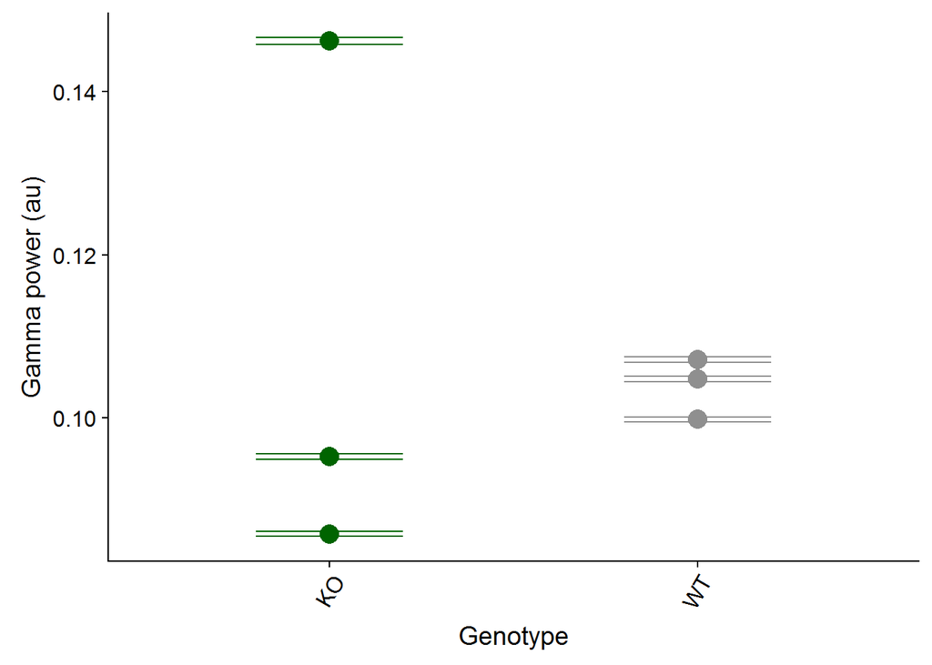

#### Theta/Delta

High values of theta/delta can indicate REM sleep. We want to look at differences in the distribution of theta/delta. The scripts plot the empirical cumulative distributions of theta/delta. If a recording has movement artifacts, these will skew the ECDF towards low values of theta/delta. So this should be approached with caution.

Plotting the cumulative frequency distributions of intervals with theta/delta in bins of 1 unit separated by genotype.

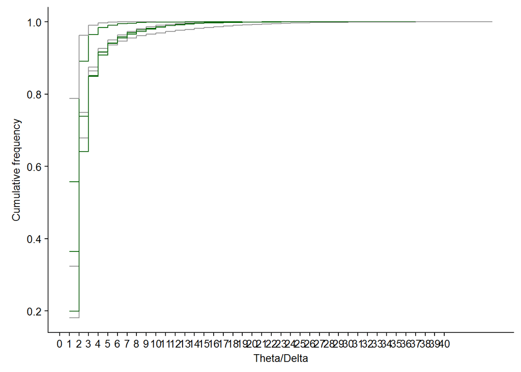

#### Spike counts

We look at the distribution of the number of spikes/interval across all intervals in each animal and compare between groups

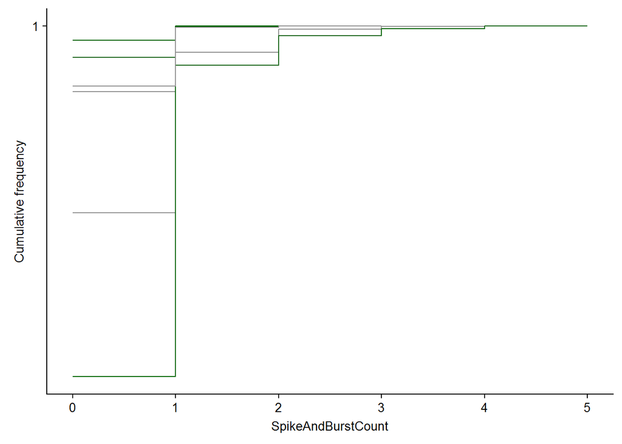

To compare between genotypes, for each animal, we extract the proportion of intervals with more than 0 spikes and write it to SummaryDataframe as a new variable Grtr0Spikes. This can be used for plotting and statisitcs

```r
#For each animal, evaluate the percentile of intervals with one or more spikes and write to the Summary dataframe

#1-ECDFCurrent$CumFrequency[1] is the number of intervals with 1 or more spikes
Grtr0Spikes<-vector()
for(i in 1:nrow(SummaryDataframe)){
  AnimalIDCurrent<-Summary$AnimalIDVariable[i]
  ECDFCurrent<-filter(ECDFAllSpikes, AnimalIDVariable==AnimalIDCurrent)
  Grtr0Spikes[i]<-1-(ECDFCurrent$CumFrequency[1])
}
Summary$Grtr0Spikes <- Grtr0Spikes
```

##### Plotting % intervals > 0 spikes

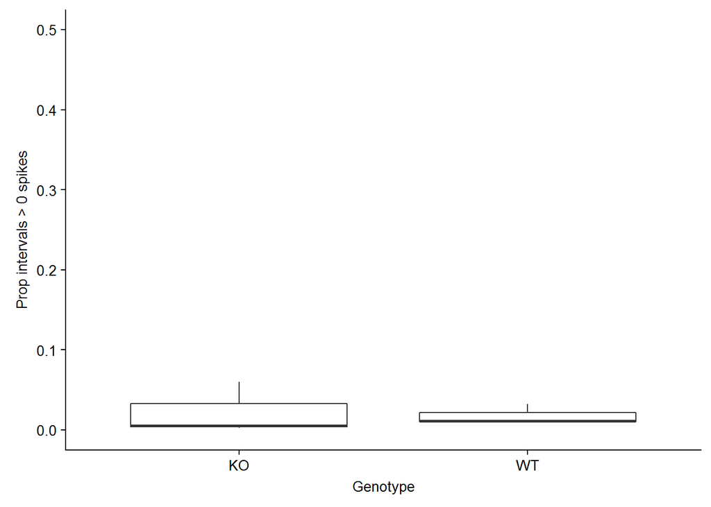

## Analysis of spectral features and spikes separated by behavioural state

If IncludeVideoScored=TRUE, we import VideoScoring data and create a dataframe of the subset of the data that has been videoscored with the behavioural state in each interval.

```r
IncludeVideoScored=TRUE
```

Create time series plots of variables showing sleep-wake by colour. The chunk iterates through all animals and saves output plots into folder ./Output/BehavioralState

### Summary data

Summarise each variable by sleep and wake, for individual animals separated by genotype

[output not shown]

| AnimalIDVariable | SleepWake | Genotype | num | MeanTheta | SEMTheta | CI_LTheta | CI_UTheta | MeanDelta | SEMDelta | CI_LDelta | CI_UDelta | MeanGamma | SEMGamma | CI_LGamma | CI_UGamma | MeanThetaOverDelta | SEMThetaOverDelta | CI_LThetaOverDelta | CI_UThetaOverDelta | RangeThetaOverDeltaL | RangeThetaOverDeltaU | SleepWakeFull | MeanSpikeAndBurst | SEMSpikeAndBurst | CI_LSpikeAndBurst | CI_USpikeAndBurst |
| --- | --- | --- | --- | --- | --- | --- | --- | --- | --- | --- | --- | --- | --- | --- | --- | --- | --- | --- | --- | --- | --- | --- | --- | --- | --- | --- |
| CDKL5_345 | S | WT | 773 | 14.90002 | 0.2518317 | 15.39438 | 14.40566 | 39.647724 | 4.2074062 | 47.907038 | 31.388411 | 4.838186 | 0.05192451 | 4.940116 | 4.736256 | 1.8314798 | 0.07001162 | 1.9689155 | 1.6940441 | 0.01056142 | 14.43721 | Sleep | 0.034928849 | 0.006607895 | 0.047900422 | 2.195728e-02 |
| CDKL5_345 | W | WT | 540 | 14.52744 | 0.2827321 | 15.08283 | 13.97205 | 33.051865 | 4.5936603 | 42.075536 | 24.028194 | 4.607604 | 0.05143721 | 4.708646 | 4.506562 | 1.7379630 | 0.08161530 | 1.8982861 | 1.5776400 | 0.01772223 | 17.50749 | Wake | 0.031481481 | 0.008785372 | 0.048739246 | 1.422372e-02 |
| CDKL5_346 | S | KO | 991 | 25.50002 | 0.3035981 | 26.09579 | 24.90425 | 21.439451 | 0.4449353 | 22.312576 | 20.566326 | 7.227861 | 0.05246842 | 7.330823 | 7.124899 | 2.0830080 | 0.08314651 | 2.2461716 | 1.9198444 | 0.30420722 | 24.79365 | Sleep | 0.004036327 | 0.002015103 | 0.007990691 | 8.196253e-05 |
| CDKL5_346 | W | KO | 360 | 28.13751 | 0.4341123 | 28.99123 | 27.28379 | 24.921008 | 0.7153183 | 26.327749 | 23.514268 | 7.025206 | 0.11959701 | 7.260404 | 6.790007 | 2.1005902 | 0.13088938 | 2.3579964 | 1.8431839 | 0.24897940 | 13.53772 | Wake | 0.005555556 | 0.003922896 | 0.013270299 | -2.159188e-03 |
| CDKL5_353 | S | WT | 1059 | 15.64433 | 0.2134315 | 16.06312 | 15.22553 | 9.159176 | 0.1510014 | 9.455472 | 8.862879 | 5.472866 | 0.03968161 | 5.550730 | 5.395002 | 2.5502833 | 0.10993639 | 2.7660015 | 2.3345652 | 0.16386966 | 31.44951 | Sleep | 0.018885741 | 0.004184889 | 0.027097368 | 1.067411e-02 |
| CDKL5_353 | W | WT | 298 | 17.27508 | 0.3880003 | 18.03866 | 16.51150 | 11.768238 | 1.1642817 | 14.059525 | 9.476951 | 5.045517 | 0.05682806 | 5.157353 | 4.933680 | 2.2178451 | 0.16397414 | 2.5405435 | 1.8951467 | 0.05377332 | 19.80050 | Wake | 0.006711409 | 0.004737687 | 0.016035099 | -2.612281e-03 |
| CDKL5_357 | S | KO | 113 | 17.37789 | 0.4448799 | 18.25937 | 16.49642 | 10.446761 | 0.5119955 | 11.461215 | 9.432308 | 6.510009 | 0.09583620 | 6.699896 | 6.320122 | 2.6776964 | 0.24146884 | 3.1561360 | 2.1992569 | 0.76486573 | 10.02946 | Sleep | 0.000000000 | 0.000000000 | 0.000000000 | 0.000000e+00 |
| CDKL5_357 | W | KO | 195 | 17.53647 | 0.5146294 | 18.55146 | 16.52148 | 28.360497 | 5.8666963 | 39.931192 | 16.789803 | 6.312390 | 0.07503068 | 6.460370 | 6.164409 | 1.9492179 | 0.11267338 | 2.1714399 | 1.7269958 | 0.03093406 | 14.95849 | Wake | 0.000000000 | 0.000000000 | 0.000000000 | 0.000000e+00 |
| CDKL5_358 | S | WT | 812 | 13.87100 | 0.1469335 | 14.15941 | 13.58258 | 31.846940 | 2.1874322 | 36.140636 | 27.553243 | 4.288968 | 0.03252552 | 4.352812 | 4.225124 | 0.7082352 | 0.02244603 | 0.7522944 | 0.6641760 | 0.01406564 | 6.42845 | Sleep | 0.006157635 | 0.002746979 | 0.011549662 | 7.656088e-04 |
| CDKL5_358 | W | WT | 531 | 14.57293 | 0.1993355 | 14.96452 | 14.18135 | 28.885911 | 0.7373489 | 30.334397 | 27.437426 | 3.912638 | 0.02360589 | 3.959011 | 3.866266 | 0.6277609 | 0.01910273 | 0.6652872 | 0.5902345 | 0.05351169 | 4.42817 | Wake | 0.001883239 | 0.001883239 | 0.005582768 | -1.816290e-03 |

### Plots

#### Delta

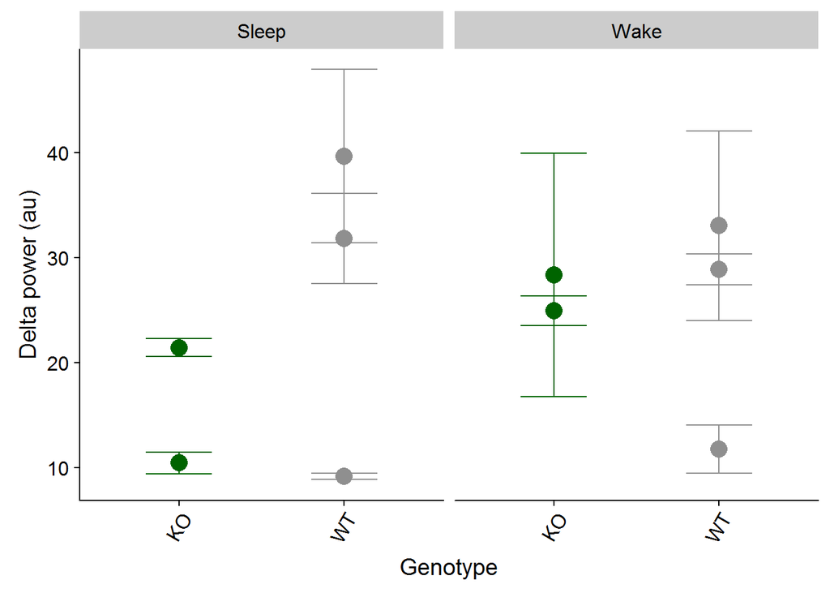

#### Theta

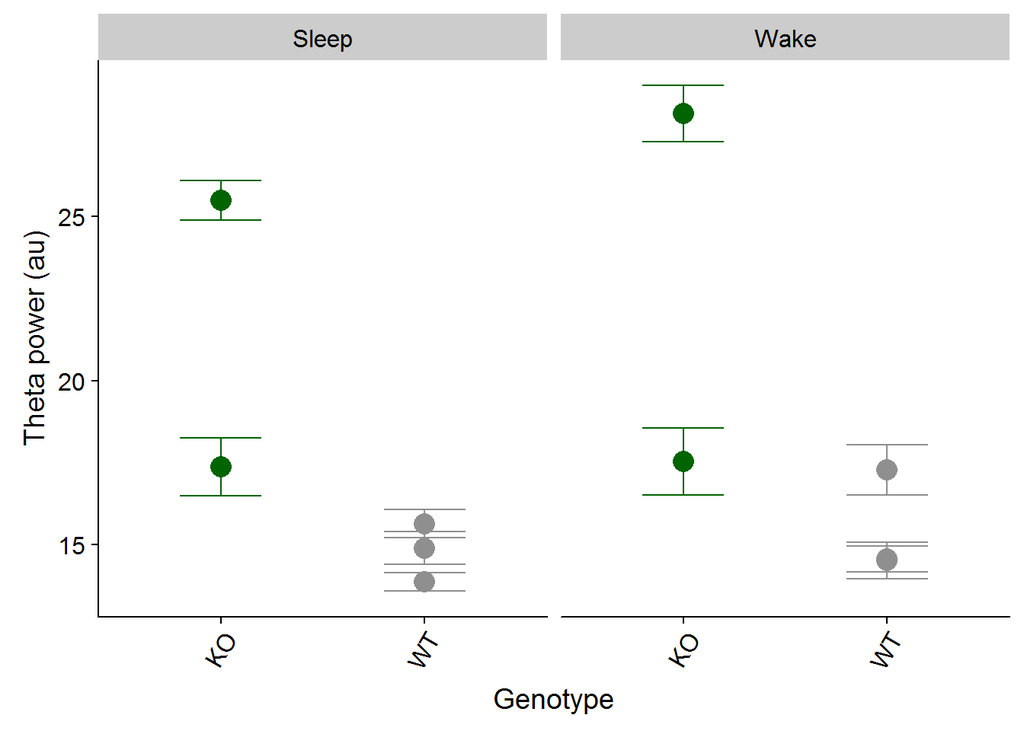

#### Gamma

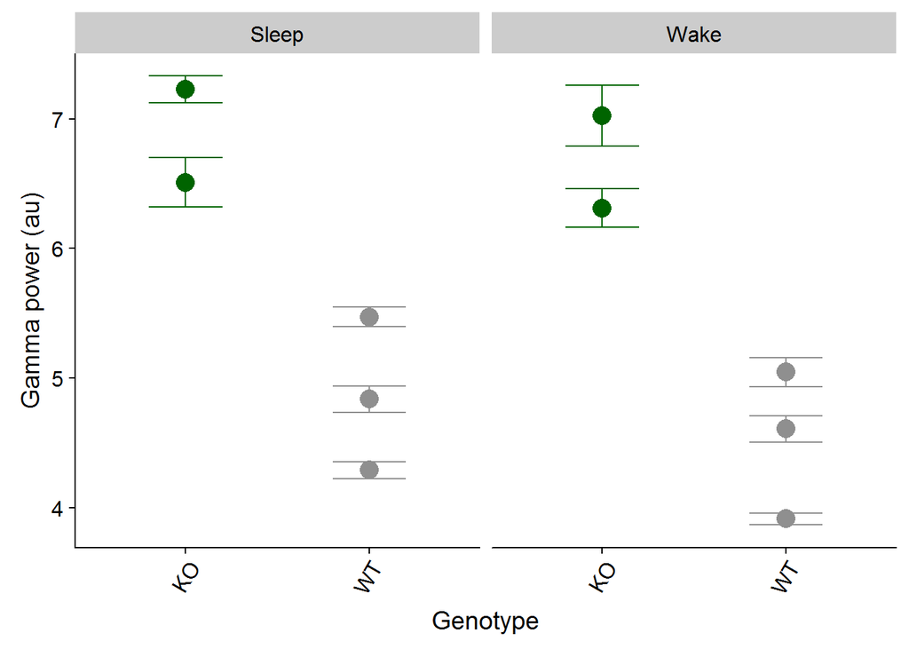

#### ThetaOverDelta

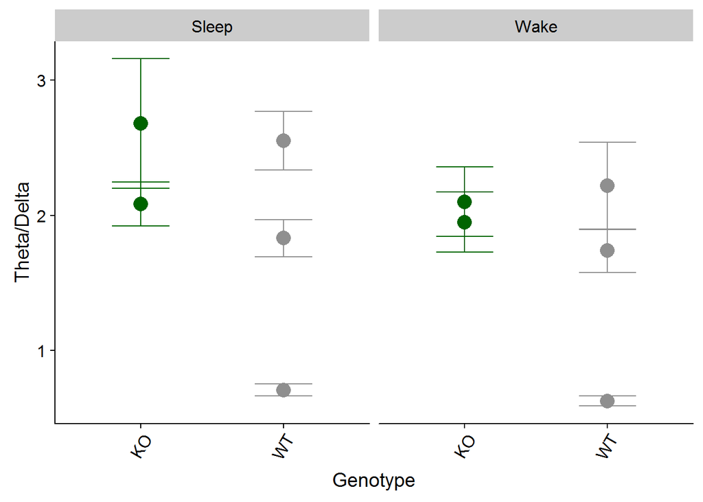

#### ThetaOverDelta Upper bound

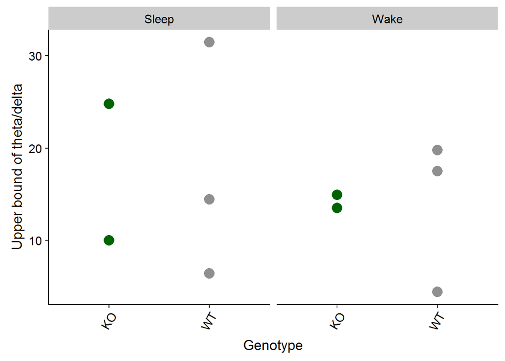

## Save Data

Write data to files

```r
write.csv(Summary, "./Output/Summary.csv")
write.csv(SummaryNorm1, "./Output/SpectralPowerSummaryBroadband1.csv")
write.csv(SummaryNorm2, "./Output/SpectralPowerSummaryBroadband2.csv")
write.csv(ECDFAllThetaOverDelta, "./Output/ECDFAllThetaOverDelta.csv")
write.csv(ECDFAllSpikes, "./Output/ECDFAllSpikes.csv")
if(IncludeVideoScored==TRUE){
  write.csv(SummarySW, "./Output/SummarySW.csv")
}
```